# Project 5

Creating data from digital sources

Philip Liman, Plim294

2024-05-22

## Part A

[Github Website](https://philiplim1509.github.io/stats220/)

[Website Explore](https://www.worldometers.info/geography/how-many-countries-in-oceania/)

My data context is the countries in Ocenia. It gives the population and subregion of the countries in Oceania.

I selected this data context because Oceania, as a geographical region, is where our home is. It also includes countries ranging from large land masses like Australia and Papua New Guinea to small island nations in the Pacific. We can also do further exploration because it provides population and subregion (this might be usefull for grouping)

```r
library(tidyverse)
library(dplyr)
library(jsonlite)
library(magick)
library(rvest)

# My data context is the countries in Ocenia. It gives the population and subregion of the countries in Oceania.

# In the https://www.worldometers.info/geography/how-many-countries-in-oceania/robots.txt, the website does not any robots txt. so it safe to assume that the website is open to web scraping.
# In the terms of conditions/disclaimer and privacy policy, they didnt specify anything related to web scraping. So, I will proceed with web scraping.



url <- "https://www.worldometers.info/geography/how-many-countries-in-oceania/"
webpage <- read_html(url)

# Create data objects
title <- webpage %>%
    html_nodes("#maincounter-wrap") %>%
    html_element("h1") %>%
    html_text()

countryCount <- webpage %>%
  html_nodes(".maincounter-number") %>%
  html_text() %>%
  str_trim %>%
  as.integer()

countries <- webpage %>%
  html_nodes("#example2 tbody tr td:nth-child(2)") %>%
  html_text()

populations <- webpage %>%
  html_nodes("#example2 tbody tr td:nth-child(3)") %>%
  html_text()

title
```

```
## [1] "Countries in Oceania:"
```

```r
countryCount
```

```
## [1] 14
```

```r
countries
```

```
##  [1] "Australia"        "Papua New Guinea" "New Zealand"      "Fiji"
##  [5] "Solomon Islands"  "Micronesia"       "Vanuatu"          "Samoa"
##  [9] "Kiribati"         "Tonga"            "Marshall Islands" "Palau"
## [13] "Nauru"            "Tuvalu"
```

```r
populations
```

```
##  [1] "26,439,111" "10,329,931" "5,228,100"  "936,375"    "740,424"
##  [6] "544,321"    "334,506"    "225,681"    "133,515"    "107,773"
## [11] "41,996"     "18,058"     "12,780"     "11,396"
```

## Part B

```r
library(tidyverse)
library(dplyr)
library(jsonlite)
library(magick)
library(rvest)

# Hon Erica Stanford

url <- "https://www.beehive.govt.nz/minister/hon-erica-stanford"

pages <- read_html(url) %>%
    html_elements(".release__wrapper") %>%
    html_elements("h2") %>%
    html_elements("a") %>%
    html_attr("href") %>%
    paste0("https://www.beehive.govt.nz", .)


get_release <- function(page_url){
  Sys.sleep(2)
  # print the page_url so if things go wrong
  # we can see which page caused issues
  print(page_url)
  page <- read_html(page_url)

  # add code to scrape the release title and release content
  release_title <- page %>%
    html_nodes("h1.article__title") %>%
    html_text() %>%
    str_trim()
  release_content <- page %>%
    html_nodes(".prose.field.field--name-body.field--type-text-with-summary.field--label-hidden.field--item") %>%
    html_text()

  # add code to return a tibble created using these data objects
  tibble(title = release_title, content = release_content)
}

release_data <- map_df(pages, get_release)

# Calculate the total number of words in all release contents
total_words <- str_count(release_data$content, "\\w+") %>% sum()

# Calculate the average number of words per release
mean_words_per_release <- mean(str_count(release_data$content, "\\w+"))

# Find the most common word in release titles
title_words <- str_split(release_data$title, "\\W+") %>% unlist() %>% tolower()
most_common_title_word <- names(sort(table(title_words), decreasing = TRUE))[1]
most_common_title_word

#Count title words
title_word_counts <- table(title_words) %>%
sort(decreasing = TRUE)
title_word_counts

# Find the most common word in release contents
content_words <- str_split(release_data$content, "\\W+") %>% unlist() %>% tolower()
most_common_content_word <- names(sort(table(content_words), decreasing = TRUE))[1]

#Count content words
content_word_counts <- table(content_words) %>%
  sort(decreasing = TRUE)
```

This is Hon Erica Stanford analysis of her released content:

The total number of words across all release contents is 8130.

The average number of words per release is 369.5454545.

The most common word in release titles is ‘to’ with a count of ‘9’.

The most common word in release contents is ‘the’ with a count of ‘410’.

## Part C

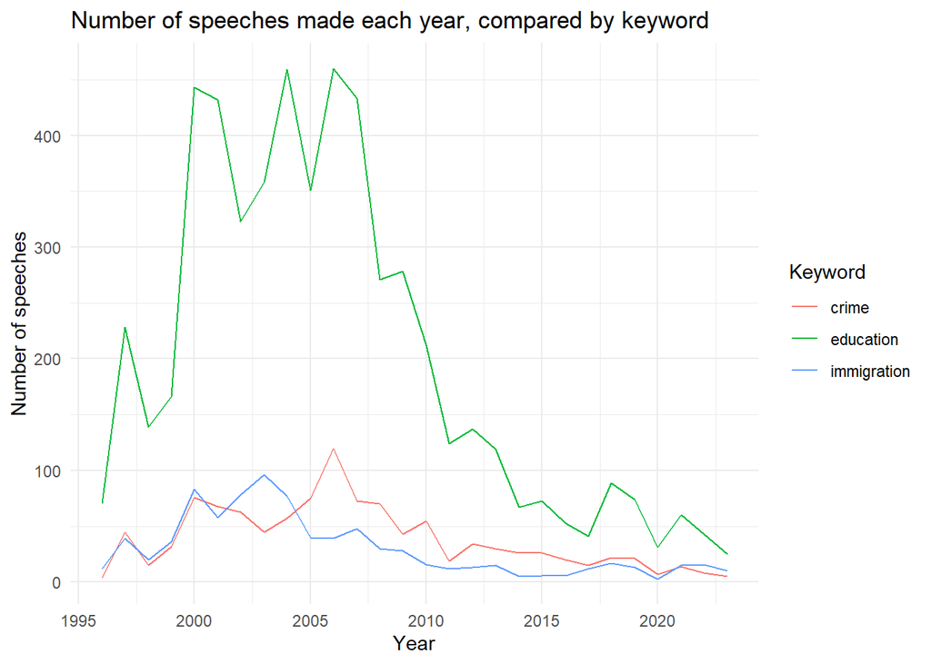

```r
library(tidyverse)
library(dplyr)
library(jsonlite)
library(magick)
library(rvest)
library(ggplot2)

keywords <- c("education", "crime", "immigration")

search1 <- read_html(paste0("https://datalandscapes.online/scrapeable/speeches.php?search=", keywords[1])) %>%
       html_elements(".speech_summary") %>%
       html_text2() %>%
       tibble(
              keyword = keywords[1],
              results = .
       ) %>%
       separate(results, into = c("year", "num_speeches"), sep = "--") %>%
       mutate(
              num_speeches = parse_number(num_speeches),
              year = parse_number(year)
       )

search2 <- read_html(paste0("https://datalandscapes.online/scrapeable/speeches.php?search=", keywords[2])) %>%
       html_elements(".speech_summary") %>%
       html_text2() %>%
       tibble(
              keyword = keywords[2],
              results = .
       ) %>%
       separate(results, into = c("year", "num_speeches"), sep = "--") %>%
       mutate(
              num_speeches = parse_number(num_speeches),
              year = parse_number(year)
       )

search3 <- read_html(paste0("https://datalandscapes.online/scrapeable/speeches.php?search=", keywords[3])) %>%
       html_elements(".speech_summary") %>%
       html_text2() %>%
       tibble(
              keyword = keywords[3],
              results = .
       ) %>%
       separate(results, into = c("year", "num_speeches"), sep = "--") %>%
       mutate(
              num_speeches = parse_number(num_speeches),
              year = parse_number(year)
       )

combined_search <- bind_rows(search1, search2, search3)
speeches_governments <- read.csv("https://docs.google.com/spreadsheets/d/e/2PACX-1vRHTFJcFmsIkjaFUCEwFWASaBOAR4X2Upx66C5Bhgc_WNc2JxxdRbbvyoewmvt_EjNdCNZZzzkENwLg/pub?gid=0&single=true&output=csv")
view(speeches_governments)
view(combined_search)

speech_data <- inner_join(combined_search, speeches_governments, by = "year")
#view(speech_data)

# Create the plot
ggplot(speech_data, aes(x = year, y = num_speeches, color = keyword)) +
  geom_line() +
  labs(title = "Number of speeches made each year, compared by keyword",
       x = "Year",
       y = "Number of speeches",
       color = "Keyword") +
  theme_minimal()
```

Immigration peaked at the year 2003, while crime and education peaked at the year 2006 (This was during the labour/progressive coalition and after their peak, all of the keywords number of speeches decrease over the year.)

## Learning reflection

One very important idea that I’ve learned from this course is data scraping. I had never used data scraping once in my entire time at university, so learning how to extract information from a website will definitely help with my major, which is BUSAN (they don’t even teach about data scraping). This also enhances my skills in data collection and pre-processing. Another key aspect is understanding where to scrape data from. Not all data is free to scrape due to legal, ethical, or technical reasons. It’s important to respect the terms of service of websites and to scrape responsibly.

Joins are also a valuable skill to learn because, in real life, not all data is going to be provided in one dataset. Most likely, we have to combine more than one, and joins are an effective way to combine datasets.

I want to learn more about advanced data scraping. For example, I could not scrape data that has interactive/hover elements in this assignment. I am also curious if we can bypass some of the robots.txt functions. If we could learn more about advanced data scraping and joins, I would be very interested.

## Self Review

The two skills I believe I have improved the most are data wrangling and visualization, and communication and reporting:

Using R, I have successfully learned how to import, clean, transform, and visualize data. The most notable skill is using code to manipulate the data (I usually use Excel for this). With R, I have gained a new skill set. Using ggplot is also helpful because it is very customizable, and there are many plots we can use. This relates back to Learning Outcome 2 (demonstrate programming concepts and skills…).

Another concept is communication and reporting. Without this course, I would have never used R Markdown to develop my reports or HTML and CSS for web-based reporting. Now, I am able to write dynamic reports using web technologies. This relates to Learning Outcome 4 (develop communication skills, using HTML…).

I want to include web scraping; however, we only briefly learned about it. I wish we could learn advanced techniques for it.

Overall, I have not only strengthened my technical skills in data wrangling and visualization but also improved my ability to effectively communicate and report my findings.